# Bootstrap

Arnaud Gloaguen, Arthur Tenenhaus

3 mai 2017

# 1 - RGCCA vs PLSR

The goal here is to compare PLSR and RGCCA in terms of results and speed. We are using PLSR because it is the core function used in ci.spls, the function we are starting to build ci.rgcca.

```r
#Clean environment
rm(list = ls())

#Load librairies
library(spls)
library(pls)
library(devtools)
library(microbenchmark)
library(ggplot2)
library(gliomaData)

#Load current work of RGCCA (branch Boostrap)
load_all("../../.")
```

Comparison of coefficients and speed

```r
data(mice)

#PLSR
Y       = scale2(mice$y, center = T, scale = T, bias = T)
X       = scale2(mice$x, center = T, scale = T, bias = T)
ncomp   = 1
method  = "simpls"
res_pls = plsr(Y ~ X, ncomp = ncomp, method = method)

#RGCCA
A               = list(x = X, y = Y)
C               = matrix(1, 2, 2) - diag(2)
tau             = c(1, 1)
ncomps          = c(1, 1)
scheme          = "factorial"
scale           = F
init            = "svd"
bias            = F
verbose         = F
scale_size_bloc = F
res_rgcca       = rgcca(A = A, C = C, tau = tau, ncomp = ncomps, scheme = scheme, scale = scale, init = init,
                        bias = bias, verbose = verbose, scale_size_bloc = scale_size_bloc)

#Correlation
cor_X = drop(cor(res_pls$projection, res_rgcca$a[[1]]))
cor_Y = drop(cor(res_pls$Yloadings, res_rgcca$a[[2]]))

cor_X
```

```
## Comp 1
##     -1
```

```r
cor_Y
```

```
## Comp 1
##     -1
```

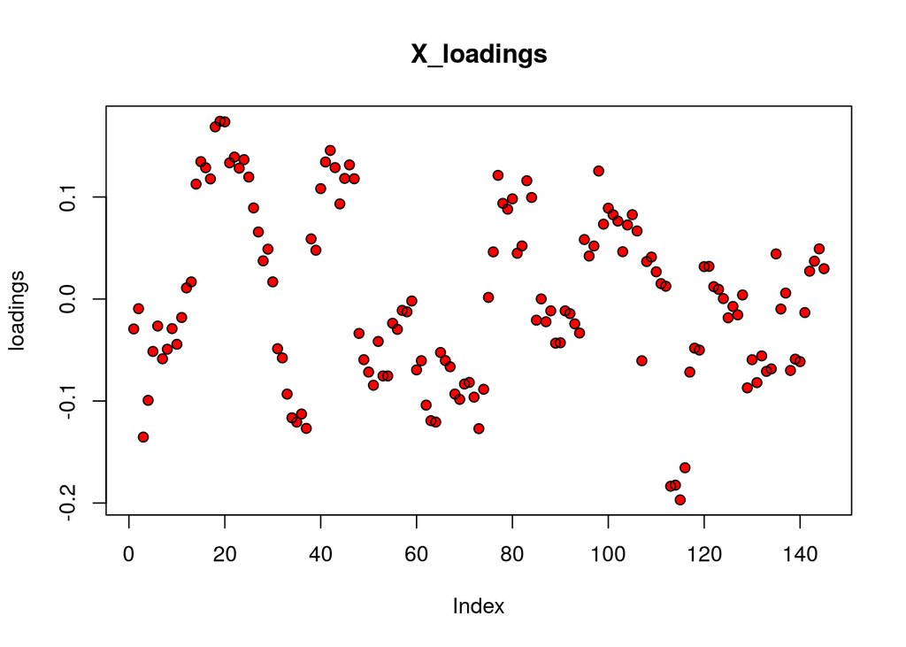

```r
#Loadings are indeed the same (just difference of normalization)
plot(cor_X*res_rgcca$a[[1]], col = "red", pch = 16, main = "X_loadings", ylab = "loadings")
points(res_pls$projection/norm2(res_pls$projection))
```

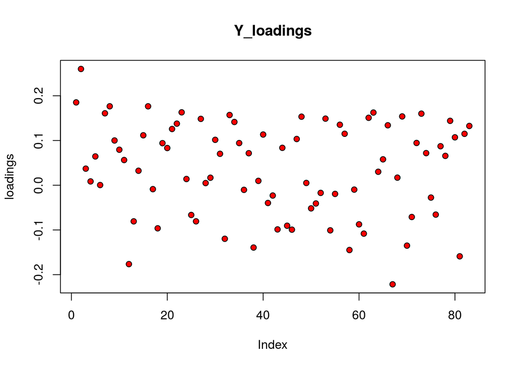

```r
plot(cor_X*res_rgcca$a[[2]], col = "red", pch = 16, main = "Y_loadings", ylab = "loadings")
points(res_pls$Yloadings/norm2(res_pls$Yloadings))
```

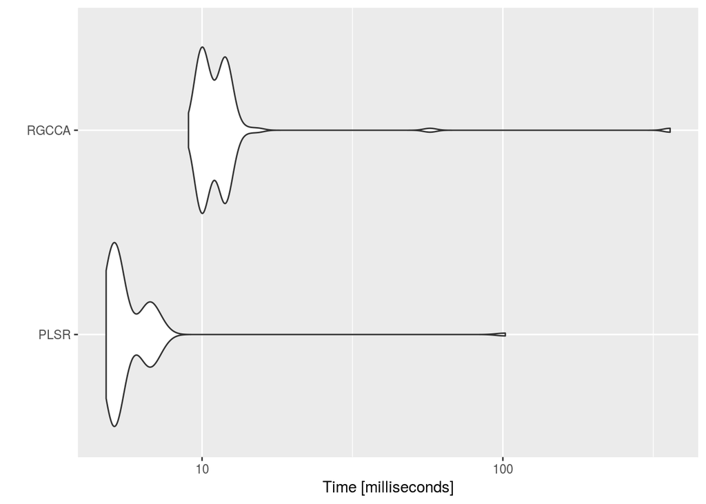

```r
#Commparison of speed.
tm = microbenchmark(PLSR  = plsr(Y ~ X, ncomp = ncomp, method = method),
                    RGCCA = rgcca(A = A, C = C, tau = tau, ncomp = ncomps, scheme = scheme, scale = scale, init = init,
                        bias = bias, verbose = verbose, scale_size_bloc = scale_size_bloc),
                    times = 100)
autoplot(tm)
```

```r
#PLSR is 2 times faster than RGCCA
TIME = tapply(X = tm$time, INDEX = tm$expr, FUN = mean)
TIME[2]/TIME[1]
```

```
##    RGCCA
## 2.288514
```

# 2 - ci.RGCCA vs ci.PLSR

Now we want to compare “ci.spls” with “ci.rgcca” in terms of speed. Indeed, as RGCCA and PLSR are giving the same result. A priori, there is no need to check that the CI are the same between the 2 techniques. We will compare the speed trough 3 different datasets : Mice/GliomaData/Russet.

## 2.1 - Mice data

Here, we still have a factor 2 between “ci.spls” and “ci.rgcca”.

```
## 10 % completed...
## 20 % completed...
## 30 % completed...
## 40 % completed...
## 50 % completed...
## 60 % completed...
## 70 % completed...
## 80 % completed...
## 90 % completed...
## 100 % completed...
```

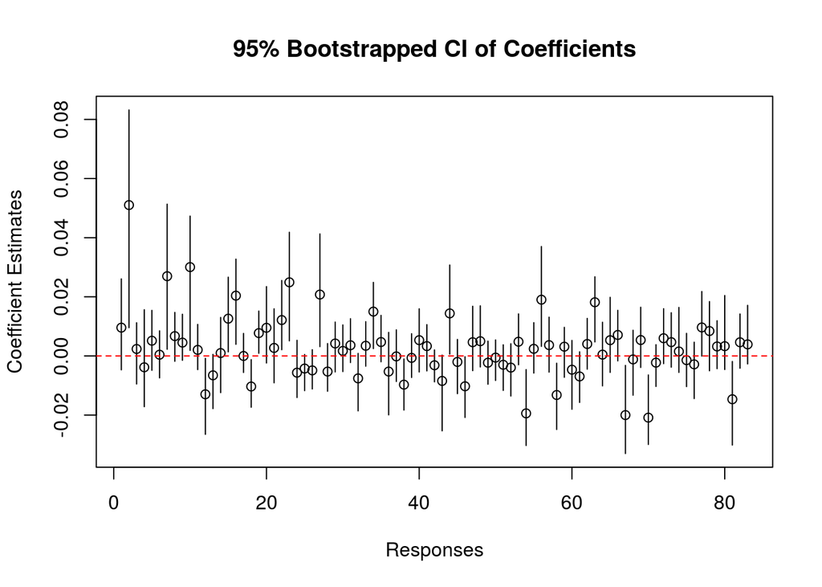

```r
data(mice)

# SPLS
f    <- spls( mice$x, mice$y, K=1, eta=0.6)
# CI with SPLS
ci.f <- ci.spls( f, plot.it=TRUE, plot.fix="x", plot.var=20 )
```

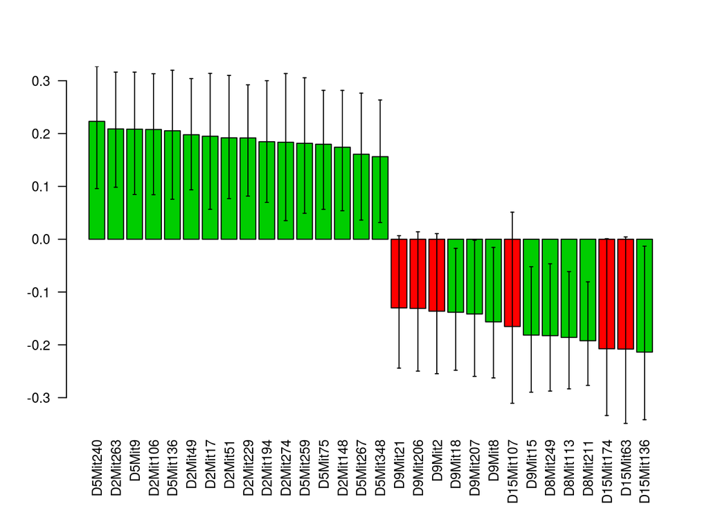

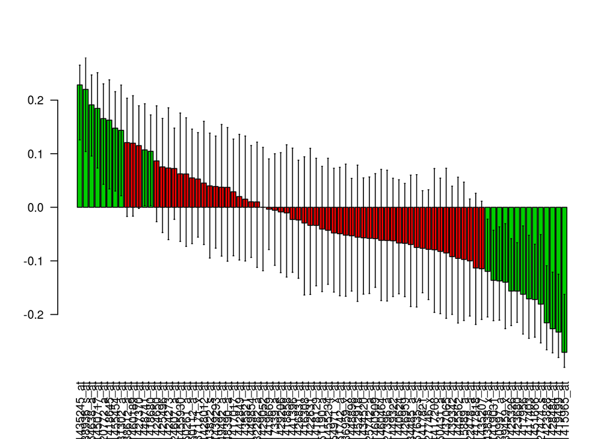

```r
#RGCCA
A               = mice
D               = A
D[[1]]          = D[[1]][,f$A]
C               = matrix(1, 2, 2) - diag(2)
tau             = c(1, 1)
ncomps          = c(1, 1)
scheme          = "factorial"
scale           = T
init            = "svd"
bias            = T
verbose         = F
scale_size_bloc = F
res_rgcca       = rgcca(A = D, C = C, tau = tau, ncomp = ncomps, scheme = scheme, scale = scale, init = init,
                        bias = bias, verbose = verbose, scale_size_bloc = scale_size_bloc)
#CI with RGCCA
B               = 1000
verbose         = T
plot            = T
ci.res_rgcca    = ci.rgcca(object = res_rgcca, A = D, B = B, verbose = verbose, plot = plot)
```

```r
#Speed
tm = microbenchmark(mice_spls = ci.spls( f, plot.it=F),
                    mice_rgcca = ci.rgcca(object = res_rgcca, A = D, B = B, verbose = F, plot = F),
                    times = 5)
```

```
## 10 % completed...
## 20 % completed...
## 30 % completed...
## 40 % completed...
## 50 % completed...
## 60 % completed...
## 70 % completed...
## 80 % completed...
## 90 % completed...
## 100 % completed...
## 10 % completed...
## 20 % completed...
## 30 % completed...
## 40 % completed...
## 50 % completed...
```

[output cut: 35 more lines]

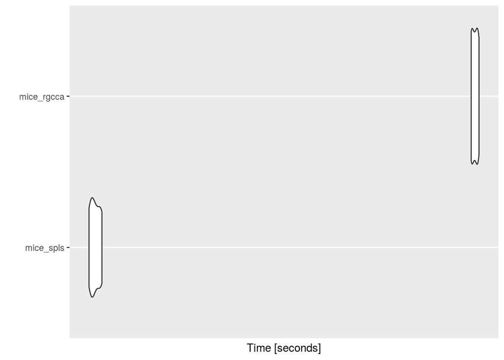

```r
autoplot(tm)
```

```r
#ci.spls is arround 2 times faster than ci.rgcca
TIME = tapply(X = tm$time, INDEX = tm$expr, FUN = mean)
TIME[2]/TIME[1]
```

```
## mice_rgcca
##   2.055666
```